# Déroulé bootstrapping, Monte-Carlo et analyse de sensibilité de Sobol

Lola Gilbert

10/05/2022

## Aim

This document aims to show how I decomposed my analysis with an emphasis on steps of bootstrapping, modelling with Monte-Carlo simulations and global sensitivity analysis of Sobol. I used a simplified dataset for the composition of prey, and used dummy data for the rest (abundance and diets of predators species).

I’ll highlight where I have trouble understanding how to apply to bootstrapp procedure you suggest to my data, or the sensitivity analysis on the parameters resulting from the bootstrapping.

# Dataset preparation

To ease computation, I used a specific table structure, with tibbles inside of tibbles.

Define abundances for 3 species in the Northeast Atlantic area (NEA) and add relevant bioenergetic data (mass and beta).

```r
data <- tibble::tribble(~ species, ~ area, ~ abundance, ~ a_CV, ~ mass, ~ beta,
                        "Bala_acu", "NEA", 10000, 0.48, 6500, 4,
                        "Delp_del", "NEA", 150000, 0.32, 80, 4,
                        "Glob_mel", "NEA", 22070, 0.22, 850, 3) |>
  # add variability around mass and beta
  dplyr::mutate(mass_min = mass - mass*0.1,
                mass_max = mass + mass*0.1,
                beta_min = beta - 0.5,
                beta_max = beta + 0.5) |>
  # nest data in dedicated columns
  tidyr::nest(mass = c(mass,
                       mass_min,
                       mass_max),
              beta = c(beta, beta_min, beta_max),
              abund = c(abundance, a_CV))
```

Define dummy diets for these 3 species using defined prey groups, defining % of weight of prey group in each species’ diet, and dummy excretion rate per element

```r
data <- data |>
  dplyr::mutate(`Large demersal energy-lean fish` = dplyr::case_when(species == "Bala_acu" ~ 10,
                                                                     species == "Delp_del" ~ 5,
                                                                     species == "Glob_mel" ~ 0),
                `Large demersal energy-rich fish` = dplyr::case_when(species == "Bala_acu" ~ 20,
                                                                     species == "Delp_del" ~ 5,
                                                                     species == "Glob_mel" ~ 0),
                `Small schooling energy-lean fish` = dplyr::case_when(species == "Bala_acu" ~ 10,
                                                                     species == "Delp_del" ~ 10,
                                                                     species == "Glob_mel" ~ 10),
                `Small schooling energy-rich fish` = dplyr::case_when(species == "Bala_acu" ~ 60,
                                                                     species == "Delp_del" ~ 70,
                                                                     species == "Glob_mel" ~ 10),
                `Miscellanous benthodemersal fish` = dplyr::case_when(species == "Bala_acu" ~ 0,
                                                                     species == "Delp_del" ~ 5,
                                                                     species == "Glob_mel" ~ 5),
                `Miscellanous pelagic fish` = dplyr::case_when(species == "Bala_acu" ~ 0,
                                                               species == "Delp_del" ~ 0,
                                                               species == "Glob_mel" ~ 5),
                `Muscular pelagic cephalopods` = dplyr::case_when(species == "Bala_acu" ~ 0,
                                                                  species == "Delp_del" ~ 5,
                                                                  species == "Glob_mel" ~ 50),
                `Bottom cephalopods` = dplyr::case_when(species == "Bala_acu" ~ 0,
                                                        species == "Delp_del" ~ 0,
                                                        species == "Glob_mel" ~ 20)
                ) |>
  # nest data in dedicated column
  tidyr::nest(diet = c(`Large demersal energy-lean fish`:`Bottom cephalopods`)) |>
  dplyr::mutate(nut_exc = seq_along(species) |>
                  purrr::map(~ tibble::tibble(N = 0.8,
                                              P = 0.7,
                                              As = 0.9,
                                              Co = 0.9,
                                              Cu = 0.9,
                                              Fe = 0.9,
                                              Mn = 0.9,
                                              Se = 0.9,
                                              Zn = 0.9)))
```

Take a look at the dataset:

```r
# to disable scientific notations
options(scipen = 999)

knitr::kable(data,
             align = 'c' ,
             booktabs = TRUE) |>
  kableExtra::kable_styling()
```

| species | area | mass | beta | abund | diet | nut_exc |
| --- | --- | --- | --- | --- | --- | --- |
| Bala_acu | NEA | 6500, 5850, 7150 | 4.0, 3.5, 4.5 | 10000.00, 0.48 | 10, 20, 10, 60, 0, 0, 0, 0 | 0.8, 0.7, 0.9, 0.9, 0.9, 0.9, 0.9, 0.9, 0.9 |
| Delp_del | NEA | 80, 72, 88 | 4.0, 3.5, 4.5 | 150000.00, 0.32 | 5, 5, 10, 70, 5, 0, 5, 0 | 0.8, 0.7, 0.9, 0.9, 0.9, 0.9, 0.9, 0.9, 0.9 |
| Glob_mel | NEA | 850, 765, 935 | 3.0, 2.5, 3.5 | 22070.00, 0.22 | 0, 0, 10, 10, 5, 5, 50, 20 | 0.8, 0.7, 0.9, 0.9, 0.9, 0.9, 0.9, 0.9, 0.9 |

Some cells are tibbles, and in this case the name of the columns are not displayed here. But they are visible when we look at the cell in particular, say for the diet for instance, for the first species:

```r
# to disable scientific notations
options(scipen = 999)

knitr::kable(purrr::pluck(data, "diet", 1),
             align = 'c' ,
             booktabs = TRUE) |>
  kableExtra::kable_styling()
```

| Large demersal energy-lean fish | Large demersal energy-rich fish | Small schooling energy-lean fish | Small schooling energy-rich fish | Miscellanous benthodemersal fish | Miscellanous pelagic fish | Muscular pelagic cephalopods | Bottom cephalopods |
| --- | --- | --- | --- | --- | --- | --- | --- |
| 10 | 20 | 10 | 60 | 0 | 0 | 0 | 0 |

For the definition of the diet, we have for each species i:

$$W_{PGi,1} + W_{PGi,2} + W_{PGi,3} + W_{PGi,4} + W_{PGi,5} + W_{PGi,6} + W_{PGi,7} + W_{PGi,8} = 100$$

# Compute the mean elemental concentration of each predator species diet - Bootstrapping as I did it in the first place

We want to compute for each predator species, the mean elemental concentration of its diet based on its relative consumption of each prey group and on the composition of each prey group. This is where I used bootstrapping : we have a dataset with the elemental concentration of a range of prey species, each being associated to a prey group (the same used for the definition of diets of predators).

I want to use bootstrapping for two reasons:

- we could compute statistical descriptors (mean, CV, min, max) to define the composition of each prey group and then use this in a Monte-Carlo procedure to do simulations, but then we would not know what distribution to apply to them. This would be a total guess… a normal distribution? a uniform ?
- we have a few samples per prey group, so it makes sense to give value to them!

A glimpse of the dataset with the composition of preys:

```r
# load dataset
load("data/Sample_dataset_LG_20220314.RData")

knitr::kable(head(nutri_df),
             align = 'c' ,
             booktabs = TRUE) |>
  kableExtra::kable_styling()
```

| Prey_group | NRJ | N | P | As | Co | Cu | Fe | Mn | Se | Zn |
| --- | --- | --- | --- | --- | --- | --- | --- | --- | --- | --- |
| Muscular pelagic cephalopods | 3.9 | 22754.58 | 1978.240 | 2.553576 | 0.0089662 | 9.8514227 | 56.063460 | 0.7026121 | 0.4524053 | 12.15898 |
| Muscular pelagic cephalopods | 3.9 | 25246.09 | 2059.787 | 3.479200 | 0.0066586 | 23.4476943 | 12.605092 | 0.4064965 | 0.6365779 | 16.21465 |
| Muscular pelagic cephalopods | 3.9 | 25840.49 | 2208.783 | 3.335906 | 0.0052984 | 8.3552448 | 2.579561 | 0.3395767 | 0.4614272 | 12.32166 |
| Small schooling energy-rich fish | 5.8 | 29652.82 | 3646.049 | 2.069499 | 0.0095385 | 0.8034402 | 18.145004 | 0.7551619 | 1.9547953 | 19.10502 |
| Small schooling energy-rich fish | 5.8 | 29693.62 | 3212.972 | 1.625070 | 0.0104936 | 0.7929185 | 16.500313 | 0.6968880 | 1.9020319 | 17.46429 |
| Small schooling energy-lean fish | 4.3 | 24810.23 | 4367.545 | 1.295067 | 0.0139162 | 0.8917514 | 20.626924 | 0.6092300 | 0.6269086 | 12.94822 |

I kept 8 prey groups for the example

```r
unique(nutri_df$Prey_group)
```

```
## [1] "Muscular pelagic cephalopods"     "Small schooling energy-rich fish"
## [3] "Small schooling energy-lean fish" "Miscellanous benthodemersal fish"
## [5] "Large demersal energy-rich fish"  "Large demersal energy-lean fish"
## [7] "Bottom cephalopods"               "Miscellanous pelagic fish"
```

The idea is to bootstrap this composition dataset to get nsim (nb of simulation that will be also used for the Monte-Carlo simulations after this, here we’ll take nsim = 100) sample per prey group, and then use these bootstrapped composition data to compute the mean composition of the diet.

I used here a basic sampling function…

```r
nsim <- 1e2

nutri_df <- nutri_df |>
  dplyr::group_by(Prey_group) |>
  dplyr::slice_sample(n = nsim, replace = TRUE)
```

```r
nutri_df |>
  dplyr::group_by(Prey_group) |>
  dplyr::summarize(n = dplyr::n())
```

```
## # A tibble: 8 x 2
##   Prey_group                           n
##   <chr>                            <int>
## 1 Bottom cephalopods                 100
## 2 Large demersal energy-lean fish    100
## 3 Large demersal energy-rich fish    100
## 4 Miscellanous benthodemersal fish   100
## 5 Miscellanous pelagic fish          100
## 6 Muscular pelagic cephalopods       100
## 7 Small schooling energy-lean fish   100
## 8 Small schooling energy-rich fish   100
```

So, for each prey group j, we have $(N_{j,1}, N_{j,2}, ..., N_{j,100})$, $(P_{j,1}, P_{j,2}, ..., P_{j,100})$, $(Fe_{j,1}, Fe_{j,2}, ..., Fe_{j,100})$, etc, for each element.

Originally, the diet data for the predator is defined in the column `diet` of `data`, as tibble with one line and 8 columns, as for the first species:

```r
knitr::kable(purrr::pluck(data, "diet", 1),
             align = 'c' ,
             booktabs = TRUE) |>
  kableExtra::kable_styling()
```

| Large demersal energy-lean fish | Large demersal energy-rich fish | Small schooling energy-lean fish | Small schooling energy-rich fish | Miscellanous benthodemersal fish | Miscellanous pelagic fish | Muscular pelagic cephalopods | Bottom cephalopods |
| --- | --- | --- | --- | --- | --- | --- | --- |
| 10 | 20 | 10 | 60 | 0 | 0 | 0 | 0 |

I then transform it in another column in the longer format, to replicate the %W per prey group data and associate each with a sample of the elemental composition of the associated prey group (so there will be 100 rows per prey group in the secondary diet tibble).

```r
full_data <- data |>
  dplyr::mutate(nut_W = seq_along(diet) |>
                  purrr::map(~ purrr::pluck(diet, .) |>
                        tidyr::pivot_longer(cols = c('Large demersal energy-lean fish':'Bottom cephalopods'),
                                     names_to = "Prey_group",
                                     values_to = "W") |>
                        # join to get a composition sample associated to each prey group
                        dplyr::left_join(y = nutri_df,
                                  by = "Prey_group")
                   ))


knitr::kable(head(purrr::pluck(full_data, "nut_W", 1), n = 6),
             align = 'c' ,
             booktabs = TRUE) |>
  kableExtra::kable_styling()
```

| Prey_group | W | NRJ | N | P | As | Co | Cu | Fe | Mn | Se | Zn |
| --- | --- | --- | --- | --- | --- | --- | --- | --- | --- | --- | --- |
| Large demersal energy-lean fish | 10 | 6.0 | 31804.76 | 3401.044 | 2.727739 | 0.0152264 | 1.9891259 | 11.868507 | 0.3469552 | 0.7463596 | 12.840912 |
| Large demersal energy-lean fish | 10 | 3.9 | 26230.92 | 3181.988 | 5.250827 | 0.0130710 | 0.4936410 | 14.042413 | 0.8366002 | 0.7489534 | 10.191356 |
| Large demersal energy-lean fish | 10 | 6.9 | 29488.52 | 2313.729 | 24.292987 | 0.0152304 | 1.5307994 | 11.781752 | 0.4714509 | 0.8592156 | 12.730894 |
| Large demersal energy-lean fish | 10 | 5.4 | 31434.22 | 2352.022 | 6.068714 | 0.0089702 | 0.3801914 | 11.858835 | 0.5213759 | 0.3546330 | 8.869226 |
| Large demersal energy-lean fish | 10 | 3.9 | 26582.11 | 4136.767 | 3.413777 | 0.0184466 | 0.3599600 | 8.231216 | 0.9583561 | 0.6424668 | 10.856333 |
| Large demersal energy-lean fish | 10 | 6.9 | 27755.06 | 1941.704 | 9.175645 | 0.0184206 | 0.4644550 | 10.138605 | 0.4263961 | 0.6487917 | 10.367234 |

Then, I compute W*elemental concentration for each prey group and each bootstrap sample associated to the prey group. For each predator species, we will thus have $(W_{PGj}\times N_{j,1}, W_{PGj}\times N_{j,2}, ..., W_{PGj}\times N_{j,100})$, $(W_{PGj}\times P_{j,1}, W_{PGj}\times P_{j,2}, ..., W_{PGj}\times P_{j,100})$, $(W_{PGj}\times Fe_{j,1}, W_{PGj}\times Fe_{j,2}, ..., W_{PGj}\times Fe_{j,100})$, etc, for each element and each prey group j (and each predator species i, but I dropped i subscript here).

```r
full_data <- full_data |>
  dplyr::mutate(
    nut_W = seq_along(nut_W) |>
      purrr::map(~ purrr::pluck(nut_W, .) |>
                   # compute W*elemental concentration
                   dplyr::mutate(NRJ = NRJ*(W/100),
                                 N = N*(W/100),
                                 P = P*(W/100),
                                 Fe = Fe*(W/100),
                                 Se = Se*(W/100),
                                 Cu = Cu*(W/100),
                                 Zn = Zn*(W/100),
                                 Mn = Mn*(W/100),
                                 Co = Co*(W/100),
                                 As = As*(W/100)) |>
                   # change it to get one column per prey_group
                   # and one line, each cell containing a full bootstrap tibble
                   # of elemental concentration, size nsim*nelements
                   # corresponding to the prey group of the column
                   dplyr::select(-c(W)) |>
                   tidyr::nest(Nut = c("NRJ":"Zn")) |>
                   tidyr::pivot_wider(names_from = Prey_group,
                                      values_from = Nut)))
```

So each nut_W cell contains a tibble with one column per prey group, and one row, each cell of this tibble being another tibble with one column per element and nsim rows, containing the $(W_{PGj}\times N_{j,1}, W_{PGj}\times N_{j,2}, ..., W_{PGj}\times N_{j,100})$, $(W_{PGj}\times P_{j,1}, W_{PGj}\times P_{j,2}, ..., W_{PGj}\times P_{j,100})$, $(W_{PGj}\times Fe_{j,1}, W_{PGj}\times Fe_{j,2}, ..., W_{PGj}\times Fe_{j,100})$, etc:

```r
# See for instance the sample of the composition of the diet portion corresponding to the consumption of
# the first prey group by the first predator species (first 6 rows):
knitr::kable(head(as.data.frame(purrr::pluck(full_data, "nut_W", 1, 1)), n = 6),
             align = 'c' ,
             booktabs = TRUE) |>
  kableExtra::kable_styling()
```

| NRJ | N | P | As | Co | Cu | Fe | Mn | Se | Zn |
| --- | --- | --- | --- | --- | --- | --- | --- | --- | --- |
| 0.60 | 3180.476 | 340.1044 | 0.2727739 | 0.0015226 | 0.1989126 | 1.1868507 | 0.0346955 | 0.0746360 | 1.2840912 |
| 0.39 | 2623.092 | 318.1988 | 0.5250827 | 0.0013071 | 0.0493641 | 1.4042413 | 0.0836600 | 0.0748953 | 1.0191356 |
| 0.69 | 2948.852 | 231.3729 | 2.4292987 | 0.0015230 | 0.1530799 | 1.1781752 | 0.0471451 | 0.0859216 | 1.2730894 |
| 0.54 | 3143.422 | 235.2022 | 0.6068714 | 0.0008970 | 0.0380191 | 1.1858835 | 0.0521376 | 0.0354633 | 0.8869226 |
| 0.39 | 2658.211 | 413.6767 | 0.3413777 | 0.0018447 | 0.0359960 | 0.8231216 | 0.0958356 | 0.0642467 | 1.0856333 |
| 0.69 | 2775.506 | 194.1704 | 0.9175645 | 0.0018421 | 0.0464455 | 1.0138605 | 0.0426396 | 0.0648792 | 1.0367234 |

Then, to get the mean elemental concentration of the diet of species i, we need to compute:

$$N_1 = W_{PG1}\times N_{1,1} + W_{PG2}\times N_{2,1} + W_{PG3}\times N_{3,1} + W_{PG4}\times N_{4,1} + W_{PG5}\times N_{5,1} + W_{PG6}\times N_{6,1} + W_{PG7}\times N_{7,1} + W_{PG8}\times N_{8,1}$$

$N_1$ being the mean N elemental concentration of the diet of i associated to sample 1. So we have to compute this sum for each sample, each element and each predator species.

```r
full_data <- full_data |>
  dplyr::mutate(# compute the mean concentration of diet by summing these values across prey_groups
         nut_diet = seq_along(nut_W) |>
           purrr::map(~ purrr::pluck(nut_W, ., 1, 1) +
                        purrr::pluck(nut_W, ., 2, 1) +
                        purrr::pluck(nut_W, ., 3, 1) +
                        purrr::pluck(nut_W, ., 4, 1) +
                        purrr::pluck(nut_W, ., 5, 1) +
                        purrr::pluck(nut_W, ., 6, 1) +
                        purrr::pluck(nut_W, ., 7, 1) +
                        purrr::pluck(nut_W, ., 8, 1) ),
         # NRJ should be a separated column as it will be used to compute the daily ration
         NRJ_diet = seq_along(nut_diet) |>
           purrr::map(~ tibble::as_tibble_col(purrr::pluck(nut_diet, ., "NRJ")*1e3)), # from kJ per g to kJ per kg
         # delete it from nut_diet tibbles
         nut_diet = seq_along(nut_diet) |>
           purrr::map(~ purrr::pluck(nut_diet, .) |>
                 dplyr::select(-NRJ))
         ) |>
  dplyr::select(-c(nut_W))
```

So now for each predator species, there is a table of the mean elemental concentration of diet considering the variability in the concentration of each prey group, with nsim rows, as here for the first species:

```r
# See for instance the sample of the composition of the diet portion corresponding to the consumption of
# the first prey group by the first predator species (first 6 rows):
knitr::kable(head(as.data.frame(purrr::pluck(full_data, "nut_diet", 1)), n = 6),
             align = 'c' ,
             booktabs = TRUE) |>
  kableExtra::kable_styling()
```

| N | P | As | Co | Cu | Fe | Mn | Se | Zn |
| --- | --- | --- | --- | --- | --- | --- | --- | --- |
| 30746.60 | 2990.508 | 3.516740 | 0.0254086 | 0.9934512 | 23.47118 | 0.8516217 | 0.7261579 | 17.58470 |
| 23946.05 | 3519.001 | 2.330450 | 0.0131182 | 0.6770011 | 10.05461 | 0.4323495 | 0.6807264 | 11.44417 |
| 30492.80 | 2832.020 | 3.864389 | 0.0147893 | 0.6274182 | 14.97107 | 0.5105229 | 0.5760161 | 13.89987 |
| 27616.18 | 3003.304 | 3.676647 | 0.0204222 | 0.8448325 | 28.11694 | 0.8413541 | 0.8236336 | 17.75054 |
| 26607.57 | 3947.689 | 2.943535 | 0.0210566 | 0.9490899 | 32.36557 | 1.8337835 | 0.5852495 | 20.61136 |
| 28675.92 | 3128.409 | 2.538626 | 0.0304416 | 3.0166571 | 42.79245 | 0.5688633 | 1.0905128 | 16.56027 |

It is these variables (the mean elemental composition of diets, $(N_1, N_2, ... N_100), (P_1, ..., P_{100}), etc$) that I consider to be parameters of the model in the following calculation. So it’s not directly the bootstrapped parameters, but it results from a calculation involving the bootstrapped parameters.

**I have two problems to apply the bootstrapp procedure that you suggest would be best to better respect the conditions to compute Sobol sensitivity analysis:**

- **I apply bootstrapping on samples of prey groups, but I have not the same number of samples for each prey group, and in particular I have one prey group with just one sample. Would it be acceptable to use one of the procedure you suggest for all prey groups but this one, and just use basic replicates for the last group with just one sample (which is what I am using at the moment with the basic sampling procedure) ? Of what I tested, there is a sufficient number of samples in the other prey groups for the procedures to work (minimum being 14 samples).**
- **as just mentioned, what I consider to be parameters of the model are not directly the bootstrapped samples but the result from a calculation involving these samples (mean elemental content of the diet and mean nrj content of the diet). Parameters involved in the calculation to obtain these “true” model parameters are the %W (ie % of prey group, in weight, in the diet of the species) of all prey groups, that do not vary, and the nutrient concentration of each prey group (all resulting from the bootstrapp procedure). Is this a problem for the sensitivity analysis ?**

## Monte-Carlo modelling

Using the same table structure I do the computation row by row and cell and by cell, cells being sometimes vectors or tables.

```r
############################# COMPUTATION ######################################
computed_data <- full_data |>
  dplyr::mutate(###### SIMULATE UNCERTAINTY IN mass, beta, abundANCE DATA, EXCRETION
    abund = seq_along(abund) |>
      purrr::map(~ abundance(abund[[.]]$abundance,
                             abund[[.]]$a_CV,
                             nsim)),
    mass = seq_along(mass) |>
      purrr::map(~ tibble::as_tibble_col(rnorm(nsim,
                                               mass[[.]]$mass,
                                               approx_se(mass[[.]]$mass_min,
                                                         mass[[.]]$mass_max)))),
    beta = seq_along(beta) |>
      purrr::map(~ tibble::as_tibble_col(rnorm(nsim,
                                               beta[[.]]$beta,
                                               approx_se(beta[[.]]$beta_min,
                                                         beta[[.]]$beta_max)))),
    nut_exc = seq_along(nut_exc) |> # nutrient excretion rate
      purrr::map(~ tibble::tibble(N = runif(n = nsim,
                                            min = nut_exc[[.]]$N - 0.1,
                                            max = nut_exc[[.]]$N + 0.1),
                   P = runif(n = nsim,
                             min = nut_exc[[.]]$P - 0.15,
                             max = nut_exc[[.]]$P + 0.1),
                   As = dplyr::case_when(nut_exc[[.]]$As == 0 ~ runif(n = nsim,
                                                                      min = 0,
                                                                      max = 0),
                                  TRUE ~ runif(n = nsim,
                                               min = nut_exc[[.]]$As - 0.05,
                                               max = nut_exc[[.]]$As + 0.05)),
                   Co = dplyr::case_when(nut_exc[[.]]$Co == 0 ~ runif(n = nsim,
                                                                      min = 0,
                                                                      max = 0),
                                  TRUE ~ runif(n = nsim,
                                               min = nut_exc[[.]]$Co - 0.05,
                                               max = nut_exc[[.]]$Co + 0.05)),
                   Cu = dplyr::case_when(nut_exc[[.]]$Cu == 0 ~ runif(n = nsim,
                                                                      min = 0,
                                                                      max = 0),
                                  TRUE ~ runif(n = nsim,
                                               min = nut_exc[[.]]$Cu - 0.05,
                                               max = nut_exc[[.]]$Cu + 0.05)),
                   Fe = dplyr::case_when(nut_exc[[.]]$Fe == 0 ~ runif(n = nsim,
                                                                      min = 0,
                                                                      max = 0),
                                  TRUE ~ runif(n = nsim,
                                               min = nut_exc[[.]]$Fe - 0.05,
                                               max = nut_exc[[.]]$Fe + 0.05)),
                   Mn = dplyr::case_when(nut_exc[[.]]$Mn == 0 ~ runif(n = nsim,
                                                                      min = 0,
                                                                      max = 0),
                                  TRUE ~ runif(n = nsim,
                                               min = nut_exc[[.]]$Mn - 0.05,
                                               max = nut_exc[[.]]$Mn + 0.05)),
                   Se = dplyr::case_when(nut_exc[[.]]$Se == 0 ~ runif(n = nsim,
                                                                      min = 0,
                                                                      max = 0),
                                  TRUE ~ runif(n = nsim,
                                               min = nut_exc[[.]]$Se - 0.05,
                                               max = nut_exc[[.]]$Se + 0.05)),
                   Zn = dplyr::case_when(nut_exc[[.]]$Zn == 0 ~ runif(n = nsim,
                                                                      min = 0,
                                                                      max = 0),
                                  TRUE ~ runif(n = nsim,
                                               min = nut_exc[[.]]$Zn - 0.05,
                                               max = nut_exc[[.]]$Zn + 0.05)))),
    ############################ COMPUTE INDIVIDUAL NRJTIC DATA, NEEDS AND CONSUMPTION OF POP ######
    Indi_data = seq_along(mass) |>
      purrr::map(~ kleber(beta = purrr::pluck(beta, ., 1), mass = purrr::pluck(mass, ., 1), n_sim = nsim,
                   assimil_mean = 0.8, assimil_se = 0.05,
                   dietQuality = purrr::pluck(NRJ_diet, ., 1))),
    # Population consumption and needs
    conso_pop = seq_along(abund) |> # Annual amount of prey consumed by the population in kg
      purrr::map(~ purrr::pluck(abund, ., 1)*365*purrr::pluck(Indi_data, ., "Ration")),
    Needs_pop = seq_along(abund) |> # Annual need of the population in kJ
      purrr::map(~ purrr::pluck(abund, ., 1)*365*purrr::pluck(Indi_data, ., "ADMR")),
    # change % to proportion for diet data
    Diet = seq_along(diet) |>
      purrr::map(~ tidyr::uncount(purrr::pluck(diet, .)/100, nsim)), # the unique line to get the same dimensions as vector to be multiplied by


    ## NUTRIENT CONSUMPTION AND EXCRETION
    conso_nut = seq_along(conso_pop) |> # Annual consumption of nutrient
      purrr::map(~ (purrr::pluck(conso_pop, .) * purrr::pluck(nut_diet, .))/1e9), # from mg to tonnes
    excrete_nut = seq_along(conso_nut) |> # Annual excretion of nutrient
      purrr::map(~ purrr::pluck(conso_nut, .) * purrr::pluck(nut_exc, .))
  )
```

The output of interest is `excrete_nut`.

## Sensitivity analysis using `sensobol`

I used the package `sensobol` presented in Puy et al. 2021 (in the References folder) as being more efficient than `sensivity`. Plus I found the example given quite clear so that I could use it in my case. I’ll show how I have done it in my case to highlight where I’m having trouble seeing how I could integrate parameters resulting from the bootstrapp process in the analysis.

I’ll show here the analysis for one species (the first one) and one nutrient (N) only, but I used a function to compute first-order and total Sobol indices for all species, all locations and all elements.

There are 5 parameters that can be included in the sensitivity analysis: the abundance of the predator species, the mass, beta, the assimilation rate and the nutrient excretion rate. Two other parameters are resulting from the bootstrapp process (again, while not being directly the bootstrapped samples) : the mean NRJ content and the mean nutrient content of the diet.

It is based on the second example exposed in Puy et al. 2021.

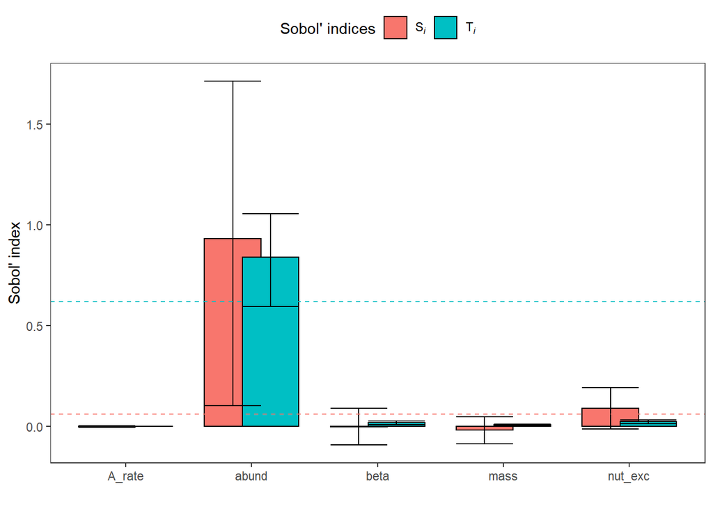

```r
rw <- 1 # just do it for the first species (ie the first row)

# create function to compute output from the matrices of parameters (one for MC parameters and one for bootstrapped parameters)
compute_y <- function(param_mat, bootstrap_mat) {
  ADMR <- param_mat[, "beta"]*293.1*(param_mat[, "mass"]^0.75)
  Ration <- ADMR / (param_mat[, "A_rate"]*purrr::pluck(bootstrap_mat, "NRJ_diet"))
  conso_pop <- param_mat[, "abund"]*365*Ration
  conso_nut <- (conso_pop*purrr::pluck(bootstrap_mat, "nut_diet"))/1e9
  excrete_nut <- conso_nut*param_mat[, "nut_exc"]

  return(excrete_nut)
}

# 1 - set parameters for the sensitivity analysis
N <- 1e2 # nb of samples
R <- 10^3 # nb of bootstrap replicas
type <- "norm" # bootstrap confidence interval method
conf <- 0.95 # length of the confidence interval
paramsN <- c("abund", "mass", "beta",
             "A_rate", "nut_exc")

# 2 - construct the sample matrix of inputs
matN <- sensobol::sobol_matrices(N = N, params = paramsN)

# 3 - change distributions of inputs according to data or bibliography/assumptions
matN[, "abund"] <- qlnorm(matN[, "abund"],
                          meanlog = log(purrr::pluck(full_data,
                                                     "abund",
                                                     rw,
                                                     "abundance") /sqrt(1 + purrr::pluck(full_data,
                                                                                     "abund",
                                                                                     rw,
                                                                                     "a_CV")*purrr::pluck(full_data,
                                                                                                          "abund",
                                                                                                          rw,
                                                                                                          "a_CV"))),
                          sdlog = sqrt(log1p(purrr::pluck(full_data,
                                                          "abund",
                                                          rw,
                                                          "a_CV")*purrr::pluck(full_data,
                                                                                   "abund",
                                                                                   rw,
                                                                                   "a_CV"))))
matN[, "mass"] <- qnorm(matN[, "mass"],
                        mean = purrr::pluck(full_data, "mass", rw, "mass"),
                        sd = (purrr::pluck(full_data, "mass", rw, "mass_max")-purrr::pluck(full_data, "mass", rw, "mass_min"))/4)
matN[, "beta"] <- qnorm(matN[, "beta"],
                        mean = purrr::pluck(full_data, "beta", rw, "beta"),
                        sd = (purrr::pluck(full_data, "beta", rw, "beta_max")-purrr::pluck(full_data, "beta", rw, "beta_min"))/4)
matN[, "A_rate"] <- qnorm(matN[, "A_rate"], mean = 0.8, sd = 0.1*0.025)
matN[, "nut_exc"] <- qunif(matN[, "nut_exc"],
                           min = purrr::pluck(full_data, "nut_exc", rw, "N") - 0.1,
                           max = purrr::pluck(full_data, "nut_exc", rw, "N") + 0.1)


mat_bootstrap_par <- tibble::tibble(NRJ_diet = purrr::pluck(full_data, "NRJ_diet", rw, 1),
                                    nut_diet = purrr::pluck(full_data, "nut_diet", rw, "N"))

# 4 - compute output
yN <- compute_y(matN, mat_bootstrap_par)

# 5 - compute sensitivity indices
indN <- sensobol::sobol_indices(Y = yN, N = N, params = paramsN,
                      boot = TRUE, R = R, type = type, conf = conf)
cols <- colnames(indN$results)[1:5]
indN$results[, (cols):= round(.SD, 3), .SDcols = (cols)]

# 6 -compute sobol indices of dummy parameters ie parameters
# that do not influence the model output,
# to estimate the approximation error
indN.dummy <- sensobol::sobol_dummy(Y = yN, N = N, params = paramsN,
                         boot = TRUE, R = R)

# 7 - identify parameters whose contribution to the output variance is less than the approximation error and can not be considered influential
# dashed lines mark the upper limit of Ti (blue) and Si (red)
plot(indN, dummy = indN.dummy)
```

We can’t still look at basic scatter plots between these parameters and the output:

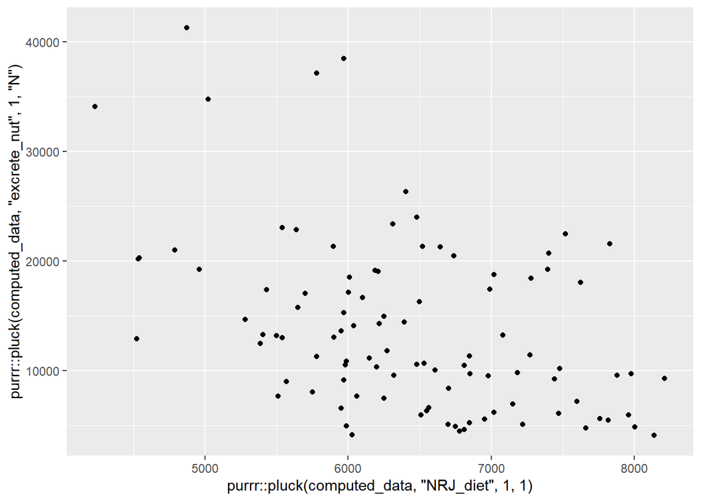

```r
ggplot2::ggplot() +
  ggplot2::geom_point(ggplot2::aes(x = purrr::pluck(computed_data, "NRJ_diet", 1, 1), y = purrr::pluck(computed_data, "excrete_nut", 1, "N")))
```

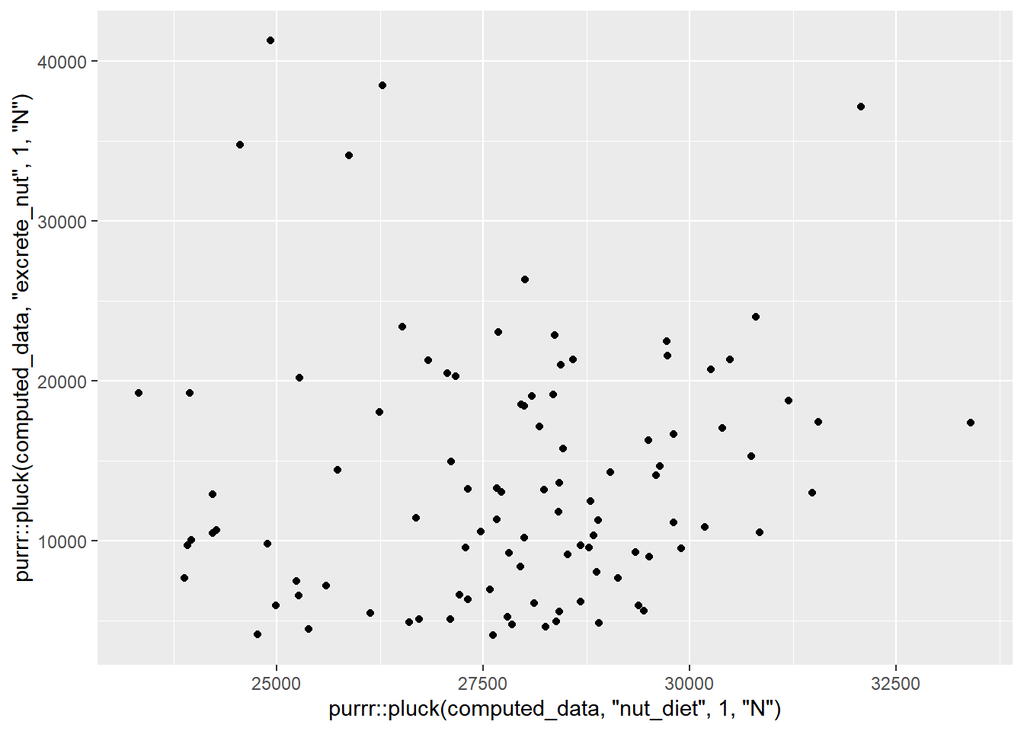

```r
ggplot2::ggplot() +
  ggplot2::geom_point(ggplot2::aes(x = purrr::pluck(computed_data, "nut_diet", 1, "N"), y = purrr::pluck(computed_data, "excrete_nut", 1, "N")))
```

These do not suggest a strong influence of the parameters on the output, but still… It would be better to include them in the sensitivity analysis!

**If I understood the bootstrapp processes you suggest I could use well, from one of them I could estimate these functions from the data (ie the samples of `nut_diet` and `NRJ_diet` resulting indirectly from the bootstrapping), is this correct ?**

**If so, then I would use one the bootstrapp process both to resample the composition of prey groups, and to estimate the distribution function of the parameters of the models resulting from a calculation involving these first bootstrapped samples. Is this okay ?**